# exploratory DA mandatory Assignment

**Importing Essential Libraries**

```python
import pandas as pd
import matplotlib.pyplot as plt
%matplotlib inline
import seaborn as sns
import numpy as np
```

**Reading the csv file of haberman datasets**

```python
df=pd.read_csv('C:\\Users\\Shubham PC\\Desktop\\haberman.csv')
df
```

|  | age | year | nodes | status |
| --- | --- | --- | --- | --- |
| 0 | 30 | 64 | 1 | 1 |
| 1 | 30 | 62 | 3 | 1 |
| 2 | 30 | 65 | 0 | 1 |
| 3 | 31 | 59 | 2 | 1 |
| 4 | 31 | 65 | 4 | 1 |
| ... | ... | ... | ... | ... |
| 301 | 75 | 62 | 1 | 1 |
| 302 | 76 | 67 | 0 | 1 |
| 303 | 77 | 65 | 3 | 1 |
| 304 | 78 | 65 | 1 | 2 |
| 305 | 83 | 58 | 2 | 2 |

306 rows × 4 columns

**data-points and features in haberman datasets**

```python
print(df.shape)
```

```
(306, 4)
```

**column names in our dataset**

```python
print(df.columns)
```

```
Index(['age', 'year', 'nodes', 'status'], dtype='object')
```

**Data points for each Status are present**

**Obervation** imbalanced datasets

```python
df['status'].value_counts()
```

```
1    225
2     81
Name: status, dtype: int64
```

## 2-D Scatter Plot

**Obervation**

- from this 2D scatter plot ,we only understand that in year of operation 1958 ,1 node is more than 50.
- in year 1967 , 1 node is 45(approx).

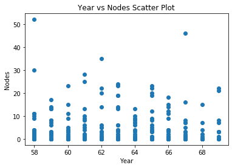

```python
plt.title("Year vs Nodes Scatter Plot")
plt.xlabel("Year")
plt.ylabel("Nodes")
plt.scatter(df.year,df.nodes)
plt.show()
```

## 2-D Scatter plot with color-coding

**Observation**

- Datapoints not much seperated.

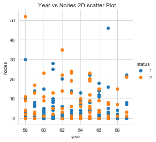

```python
sns.set_style("whitegrid");
sns.FacetGrid(df, hue="status", size=4) \
   .map(plt.scatter,"year", "nodes") \
   .add_legend();
plt.title(" Year vs Nodes 2D scatter Plot")
plt.show();
```

**Observation** Not much seperated

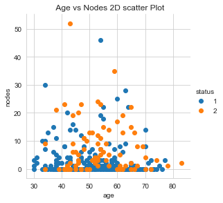

```python
sns.set_style("whitegrid");
sns.FacetGrid(df, hue="status", size=4) \
   .map(plt.scatter, "age", "nodes") \
   .add_legend();                                                 # not much seperated
plt.title(" Age vs Nodes 2D scatter Plot")
plt.show();
```

**Observation** Not much seperated

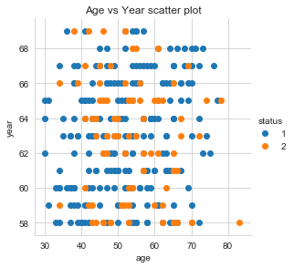

```python
sns.set_style("whitegrid");
sns.FacetGrid(df, hue="status", size=4) \
   .map(plt.scatter, "age", "year") \
   .add_legend();                      # not much seperated
plt.title("Age vs Year scatter plot")
plt.show();
```

## 1D Scatter Plot

**Observation** cannot determine much while seeing 1D Scatter plot

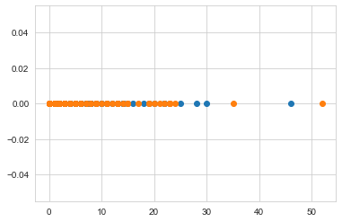

```python
import numpy as np                                                           # 1D Scatter Plot
df_1 = df.loc[df["status"] == 1];
df_2 = df.loc[df["status"] == 2];

plt.plot(df_1["nodes"], np.zeros_like(df_1['nodes']), 'o')
plt.plot(df_2["nodes"], np.zeros_like(df_2['nodes']), 'o')            # cannot determine much while seeing 1D Scatter plot
plt.show()
```

## Pair Plot

[output not shown]

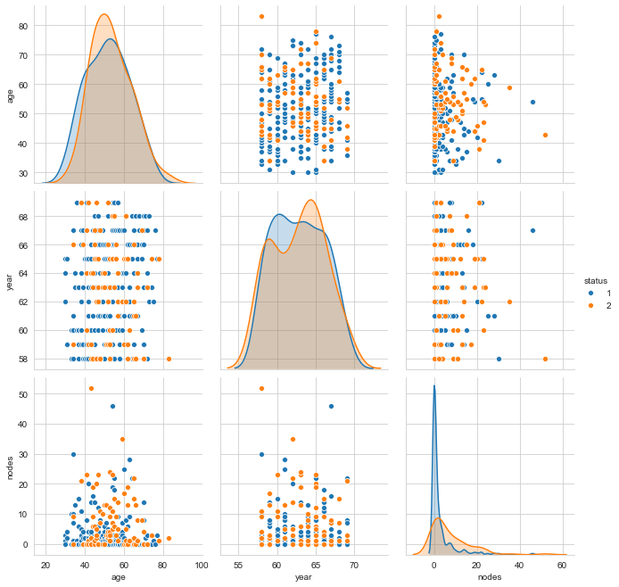

```python
plt.close();
sns.set_style("whitegrid");
sns.pairplot(df, hue="status", size=3);
plt.show()
```

# Histogram

**Observation** nodes with value between 0 and 2,majority of the patient survived 5 years or longer

[output not shown]

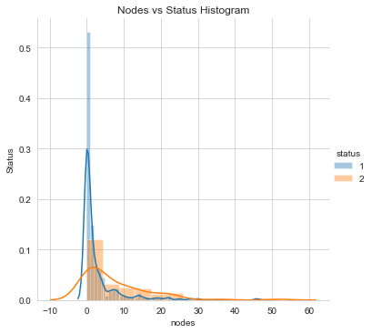

```python
sns.FacetGrid(df, hue="status", size=5) \
   .map(sns.distplot, "nodes") \
   .add_legend();

plt.title("Nodes vs Status Histogram")
plt.ylabel("Status")
plt.show();
```

**Histogram-- Status vs Year**

[output not shown]

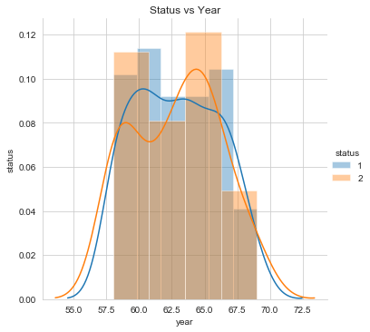

```python
sns.FacetGrid(df, hue="status", size=5) \
   .map(sns.distplot, "year") \
   .add_legend();

plt.title("Status vs Year")
plt.ylabel("status")
plt.show();
```

# Mean and Std-Dev

**Obsevations** *mean nodes of status 1 patients is 2.7911111111111113

*mean nodes of status 2 patients is 7.45679012345679

*std. deviation( avg distance of all the nodes from the mean value) of status 1 patients is 5.85725844941213

*std. deviation( avg distance of all the nodes from the mean value) of status 2 patients is 9.128776076761632

```python
print("Means:")                                # mean nodes of status 1 patients is 2.7911111111111113.
print(np.mean(df_1["nodes"]))                  # mean nodes of status 2 patients is 7.45679012345679
print(np.mean(df_2["nodes"]))

print("\nStd-dev:");
print(np.std(df_1["nodes"]))                  # std. deviation( avg distance of all the nodes from the mean value) of status 1 patients is 5.857258449412131
print(np.std(df_2["nodes"]))                  # std. deviation( avg distance of all the nodes from the mean value) of status 2 patients is 9.128776076761632
```

```
Means:
2.7911111111111113
7.45679012345679

Std-dev:
5.857258449412131
9.128776076761632
```

# Box Plot

**Observation** *i observed that the 50 percentile value of the patient died within 5 year is 4

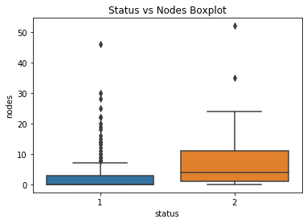

```python
sns.boxplot(x='status',y='nodes', data=df)  # i observed that the 50 percentile value of the patient died within 5 year is 4
plt.title("Status vs Nodes Boxplot")
plt.show()
```

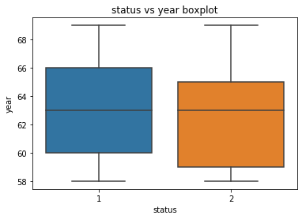

```python
sns.boxplot(x='status',y='year', data=df)
plt.title("status vs year boxplot")
plt.show()
```

# Violin Plot

**Observation** *median of the patients died within 5 year is 4

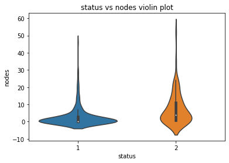

```python
sns.violinplot(x="status", y="nodes", data=df, size=8)      #median of the patients died within 5 year is 4
plt.title("status vs nodes violin plot")
plt.show()                                                  #meadin of the patients the patient survived 5 years or longer is 1(approx)
                                                            # interquartile range of 2 is from 0 to 12 ie 50% of nodes lies in this range ,and for 1 is from 1 to 8.
```

## Qantiles

**Observations**

*0th,25th,50th,75th percentile nodes value for status 2 are 0,1,4 and 11 respectively (ie min value of nodes is 0 ...at value 1, 25% of data is before it...at value 4, 50% of data is before it... at value 11,75% data is before that value)

```python
print("\nQuantiles:")
print(np.percentile(df_1["nodes"],np.arange(0, 100, 25)))    # 0th,25th,50th,75th percentile nodes value for status 1 are 0,0,0 and 3 respectively (ie min value of nodes is 1 ....... at value 3, 75% data is before that value)
print(np.percentile(df_2["nodes"],np.arange(0, 100, 25)))    # 0th,25th,50th,75th percentile nodes value for status 2 are 0,1,4 and 11 respectively (ie min value of nodes is 0 ...at value 1, 25% of data is before it...at value 4, 50% of data is before it... at value 11,75% data is before that value)
```

```
Quantiles:
[0. 0. 0. 3.]
[ 0.  1.  4. 11.]
```

## Median Absolute Deviation

**Observations**

- MAD for status 1 nodes is 0.0 ,ie, nodes of status 1 are at deviation of 0 from central tendency.
- MAD for status 2 nodes is 5.930408874022408 ,ie, nodes of status 2 are at deviation of 5.930408874022408 from central tendency

```python
from statsmodels import robust                     # MAD for status 1 nodes is 0.0 ,ie, nodes of status 1 are at deviation of 0 from central tendency
print ("\nMedian Absolute Deviation")              # MAD for status 2 nodes is 5.930408874022408 ,ie, nodes of status 2 are at deviation of 5.930408874022408 from central tendency
print(robust.mad(df_1["nodes"]))
print(robust.mad(df_2["nodes"]))
```

```
Median Absolute Deviation
0.0
5.930408874022408
```